# Week1 Lab_홍익선

Bayesian Belief Update

```python
import numpy as np
np.set_printoptions(precision=3)
import pandas as pd
pd.set_option('display.precision', 3)
import matplotlib.pyplot as plt
import math
```

Case1: Beta-Binomial (unknown p)

```python
from scipy.stats import binom, beta
```

Sampling Density

Every statistical inference or prediction should always start first with the assumption on sampling density , i.e. data generating process. In this case, we have a data set from a classical coin toss, yi∈{0,1} , where yi=1 with a probability p , and our goal is to make Bayesian inference on the parameter p .

```python
# population parameter
p = 0.3
# generate toy sample
N = 15
np.random.seed(101)
data = binom.rvs(1,p, size=N)
print(data)
print(data.size)
print(data.sum())
```

```
[0 0 0 0 0 1 0 1 1 0 0 0 0 1 1]
15
5
```

Prior Belief

Prior belief can be in any form (flat, peaked, skewed, bimodal...) as long as the belief satistifies the fundamental axioms of probability. We choose beta distribution to express our belief solely because of its analytic convenience, that is, the resulting posterior can be integrated.

```
[0.    0.01  0.02  0.03  0.04  0.051 0.061 0.071 0.081 0.091 0.101 0.111
 0.121 0.131 0.141 0.152 0.162 0.172 0.182 0.192 0.202 0.212 0.222 0.232
 0.242 0.253 0.263 0.273 0.283 0.293 0.303 0.313 0.323 0.333 0.343 0.354
 0.364 0.374 0.384 0.394 0.404 0.414 0.424 0.434 0.444 0.455 0.465 0.475
 0.485 0.495 0.505 0.515 0.525 0.535 0.545 0.556 0.566 0.576 0.586 0.596
 0.606 0.616 0.626 0.636 0.646 0.657 0.667 0.677 0.687 0.697 0.707 0.717
 0.727 0.737 0.747 0.758 0.768 0.778 0.788 0.798 0.808 0.818 0.828 0.838
 0.848 0.859 0.869 0.879 0.889 0.899 0.909 0.919 0.929 0.939 0.949 0.96
 0.97  0.98  0.99  1.   ]
```

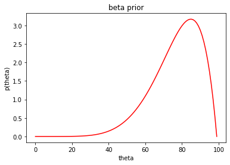

```python
# choose your belief parameter
a= 7; b= 2

prior = beta(a, b)
theta = np.linspace(0,1,100)
print(theta)
plt.plot(prior.pdf(theta), color='r')
plt.title('beta prior')
plt.xlabel('theta')
plt.ylabel('p(theta)')
```

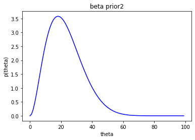

```python
# you can always reflect other belief by tweaking your parameter;
a2= 3; b2= 10

prior2 = beta(a2, b2)
theta = np.linspace(0,1,100)
plt.plot(prior2.pdf(theta), color='b')
plt.title('beta prior2')
plt.xlabel('theta')
plt.ylabel('p(theta)')
```

Likelihood (Sampling Density)

Once you have specified your belief, you need to consider "how likely" the data is at each point of p . What you would really come in handy is a plot where every possible choice of p is on x-axis and the y-axis shows "how likely the data came from that choice of p . Likelihood does exactly this.

```
(0, 0.0005)
```

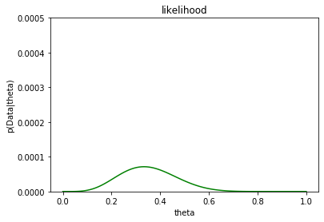

```python
# scipy stats package does not allow for plotting pdf-theta so we need to define formula directly.
def likelihood(D, p):
    N = D.size; suc = D.sum()
    theta = np.linspace(0,1,100)
    return p**suc * (1-p)**(N-suc) # note that we neglected the constant as it will be canceled out in appling Bayes Rule

plt.plot(theta, likelihood(data, theta), color='g')
plt.title("likelihood")
plt.xlabel("theta")
plt.ylabel("p(Data|theta)")
plt.ylim(0,0.0005)
```

Posterior: Updated Belief

The posterior is defined by strictly applying Bayes Rule; p(θ|D)=p(θ)p(D|θ)∫p(θ)p(D|θ)dθ . This is in most cases analytically intractable, but in this case where we have a conjugacy between the belief distribution and the sampling distribution, this simply reduces to updating belief paratemers; a, b. Otherwise we have to approximate p(θ|D) or use numerical methods, such as MCMC.

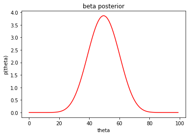

```python
# Belief update

a_pos = a + data.sum()
b_pos = b + data.size - data.sum()

posterior = beta(a_pos, b_pos)
theta = np.linspace(0,1,100)
plt.plot(posterior.pdf(theta), color='r')
plt.title('beta posterior')
plt.xlabel('theta')
plt.ylabel('p(theta)')
```

```
(0, 4)
```

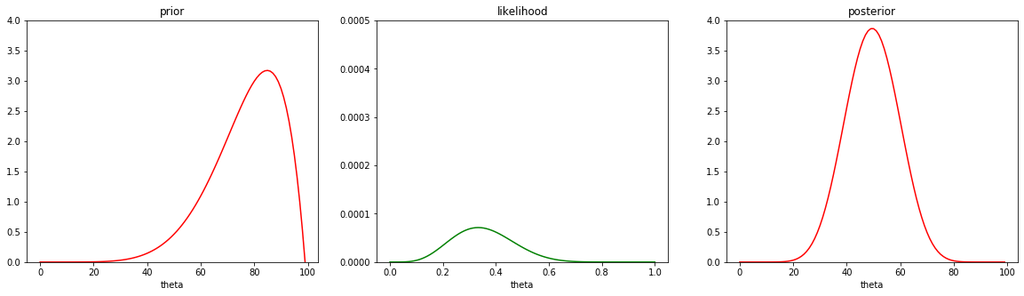

```python
# in a nutshell;
fig = plt.figure(figsize=(20,5))

ax1 = fig.add_subplot(131)
ax1.plot(prior.pdf(theta), color='r')
ax1.set_title('prior')
ax1.set_xlabel('theta')
ax1.set_ylim(0,4)

ax2 = fig.add_subplot(132)
ax2.plot(theta, likelihood(data, theta), color='g')
ax2.set_title('likelihood')
ax2.set_xlabel('theta')
ax2.set_ylim(0,0.0005)

ax3 = fig.add_subplot(133)
ax3.plot(posterior.pdf(theta), color='r')
ax3.set_title('posterior')
ax3.set_xlabel('theta')
ax3.set_ylim(0,4)
```

(HW) Case 2: Gaussian(prior)-Gaussian(likelihood) (unknown mu, known precision)

```python
from scipy.stats import norm

# population parameter
u = 15; sigma2=10
# generate toy sample
N = 20
np.random.seed(10)
dataset = norm.rvs(loc=u, scale=math.sqrt(sigma2), size=N)
print(dataset)
print(dataset.size)
```

```
[19.211 17.262 10.113 14.973 16.965 12.723 15.84  15.343 15.014 14.448
 16.369 18.804 11.948 18.252 15.723 16.408 11.406 15.427 19.695 11.585]
20
```

Prior belief

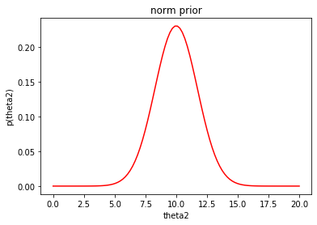

```python
#choose my belief parameter
mu=10 ; s=3
#prior = norm(loc=mu, scale=s2**(1/2))
theta2 = np.linspace(0, 20, 100)
plt.plot(theta2, norm.pdf(theta2, mu, math.sqrt(s)), color='r')
plt.title('norm prior')
plt.xlabel('theta2')
plt.ylabel('p(theta2)')
```

Likelihood

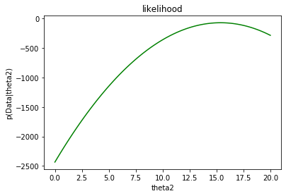

```python
def log_likelihood(D, mu):
    res=[]
    for i in mu:
        res.append(-np.square((D-i)).sum()/2)
    return res

plt.plot(theta2, log_likelihood(D=dataset, mu=theta2), color='g')
plt.title("likelihood")
plt.xlabel("theta2")
plt.ylabel("p(Data|theta2)")
```

Posterior

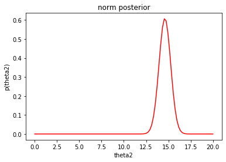

```python
# Belief update
mu_post = ((mu/s)+(N/sigma2)*np.mean(dataset))/((1/s)+(N/sigma2))
sigma2_post = 1/((1/s)+(N/sigma2))

plt.plot(theta2, norm.pdf(theta2, mu_post, math.sqrt(sigma2_post)), color='r')
plt.title('norm posterior')
plt.xlabel('theta2')
plt.ylabel('p(theta2)')
```

```python
sigma2_post
```

```
0.42857142857142855
```

```
(0, 1)
```

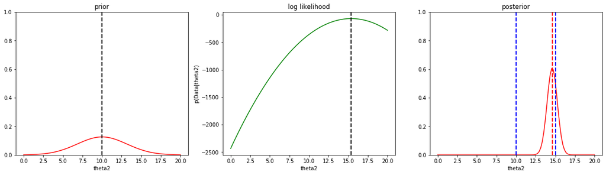

```python
# in a nutshell;
fig = plt.figure(figsize=(20,5))

ax1 = fig.add_subplot(131)
ax1.plot(theta2, norm.pdf(theta2, mu, math.sqrt(sigma2)), color='r')
ax1.set_title('prior')
ax1.set_xlabel('theta2')
ax1.axvline(x=10, color='k', linestyle='--', linewidth=2)
ax1.set_ylim(0,1)

ax2=fig.add_subplot(132)
ax2.plot(theta2, log_likelihood(D=dataset, mu=theta2), color='g')
ax2.set_title("log likelihood")
ax2.axvline(x=np.mean(dataset), color='k', linestyle='--', linewidth=2)
ax2.set_xlabel("theta2")
ax2.set_ylabel("p(Data|theta2)")

ax3 = fig.add_subplot(133)
ax3.plot(theta2, norm.pdf(theta2, mu_post, math.sqrt(sigma2_post)), color='r')
ax3.axvline(x=mu_post, color='r', linestyle='--', linewidth=2)
ax3.axvline(x=mu, color='b', linestyle='--', linewidth=2)
ax3.axvline(x=15, color='b', linestyle='--', linewidth=2)

ax3.set_title('posterior')
ax3.set_xlabel('theta2')
ax3.set_ylim(0,1)
```